# kmeans clustering project

Ali

10/04/2020

# about the app

This is an R Shiny application . it allows users to preprocess data and run a k means analysis , the results returned are information about the clustering process ( clusters,centers ,other parameters ) , a scatter plot showing these clusters and 2 heatmaps corresponding to the processed data matrix and its transpose .

For more details on using R shiny see https://shiny.rstudio.com.

# kmeans clustering alghorithm

## first what is clustering ?

Cluster analysis or clustering is the task of grouping a set of objects in such a way that objects in the same group (called a cluster) are more similar (in some sense) to each other than to those in other groups (clusters).

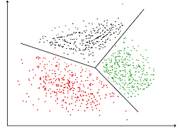

# kmeans

kmeans is just a method (alghorithm) to cluster data

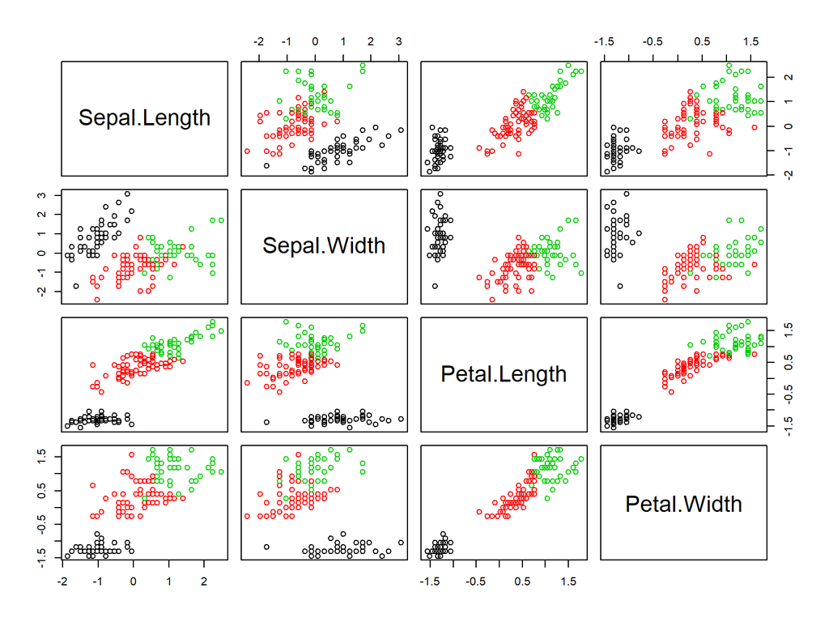

```r
data<-iris[,1:4] #we must keep only numeric features
scaled_data<-scale(data) #normalize data
kfit=kmeans(data ,3) #lets suppose we want three clusters
pairs(scaled_data , col= kfit$cluster)#plot
```

# How it works

1/ click the **start** button

2/ chose one of the existing datsets or import your data ( the features (columns) should be mostly numeric ) then submit

3/ chose the number of clusters you want to get and run analysis

4/ you can switch the number of the clusters and observe the changes instantly.

# Notes

This is my first shiny application ,I know that practicaly this app isn’t very useful but the purpose is to learn how to use the shiny framework

please dont hesitate to write me your feedbacks.

thank you.